[O’Hara on GitHub](https://github.com/oharac)

# Plot map of impact and intensification quadrants

Compiled on Fri May 29 10:08:23 2020 by ohara

```r
library(raster)
library(sf)
source('https://raw.githubusercontent.com/oharac/src/master/R/common.R')

source(here('common_fxns.R'))

reload <- FALSE
```

# 1 Summary

Using impact maps and intensification maps, create a map dividing the ocean into four categories:

- High impact, intensifying
- Low impact, intensifying
- High impact, deintensifying
- Low impact, deintensifying

For now this will be done at the stressor group level and cumulative level.

# 2 Methods

## 2.1 Gather the necessary maps and reclassify

High and low impact will be represented by the cells with the top 20% and bottom 20% of proportional species impact. High and low intensification will be the top 20% (?) of each.

Here we reclassify the impact map (2013 cumulative for stressor groups and overall) to two values (and zero for neutral):

$$\begin{align*}
impact_{reclass} = \begin{cases}
+1 &\text{when high impact}\\
-1 &\text{when low impact}\\
0 &else
\end{cases}
\end{align*}$$

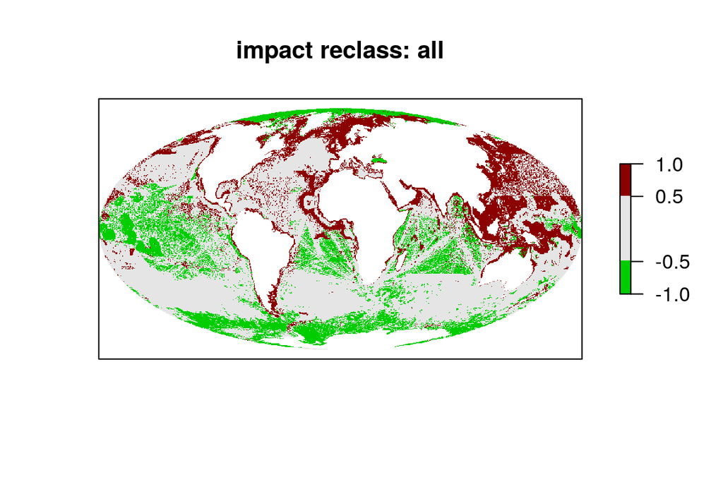

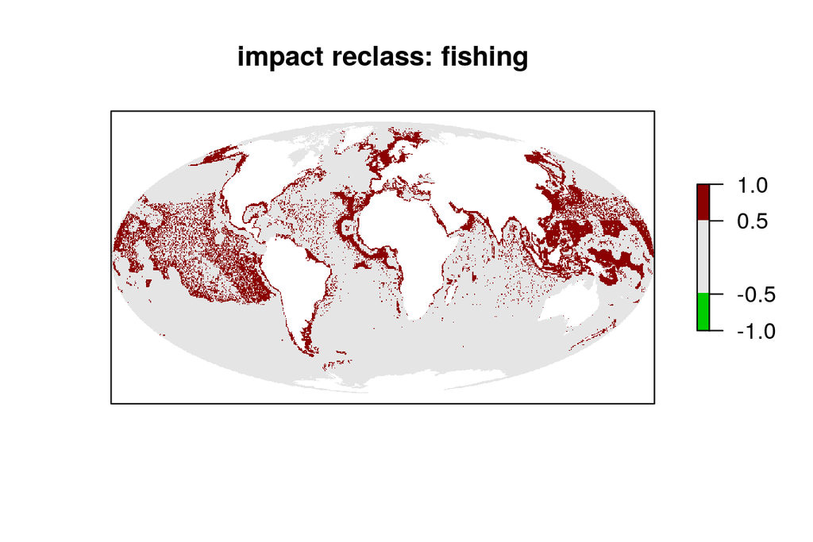

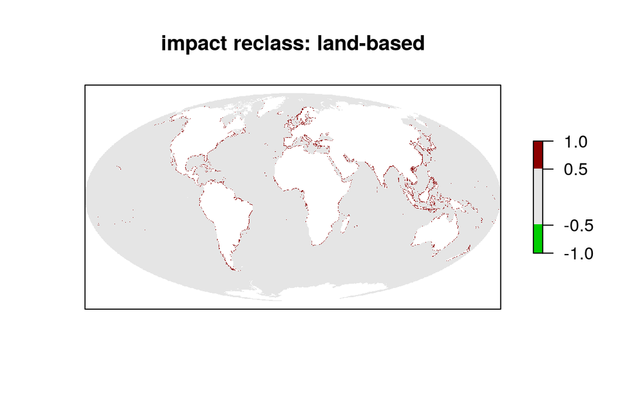

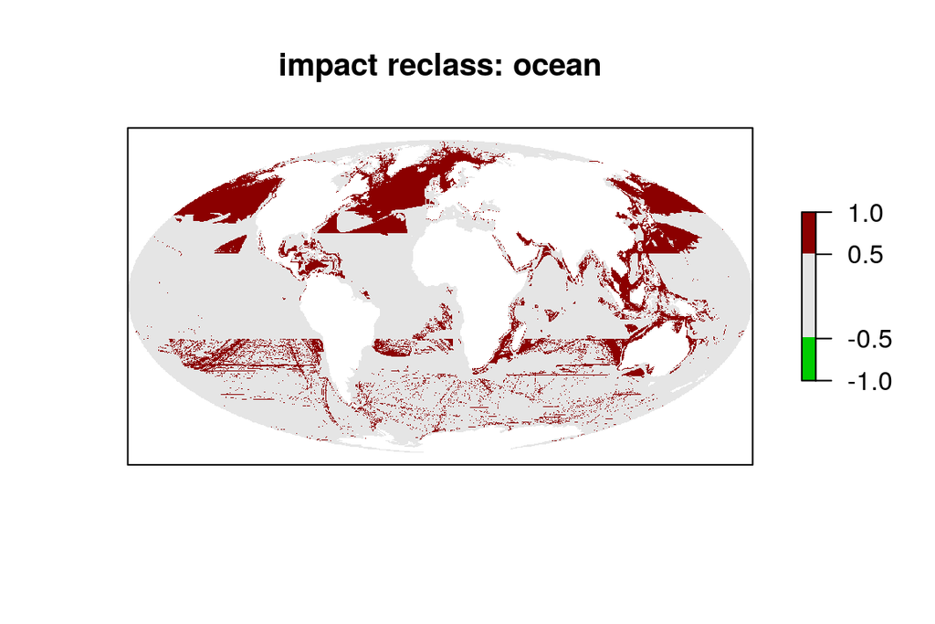

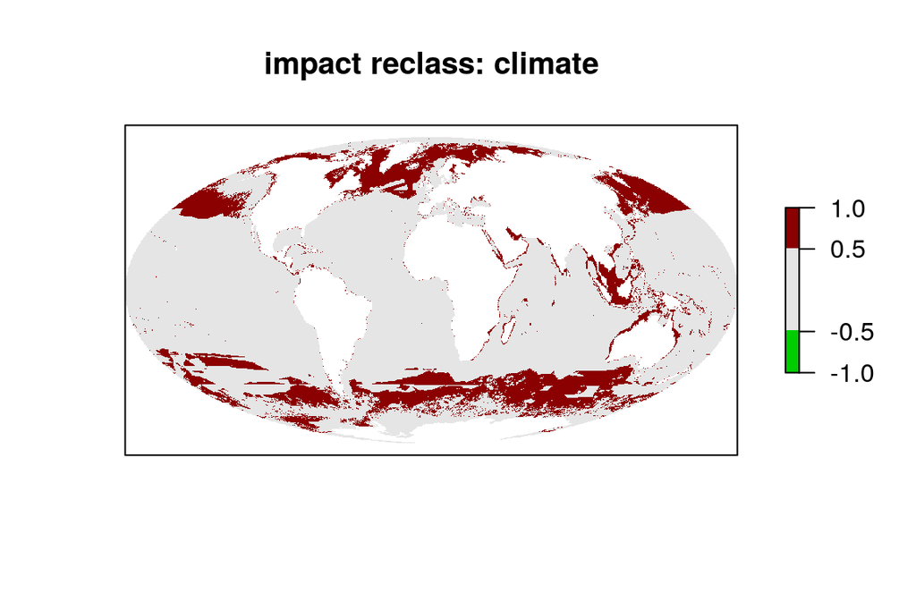

Here we reclassify the intensification maps (cumulative for stressor groups and overall) to two values (and zero for neutral):

$$\begin{align*}
intensification_{reclass} = \begin{cases}
+1 &\text{when high intensification}\\
-1 &\text{when high deintensification}\\
0 &else
\end{cases}
\end{align*}$$

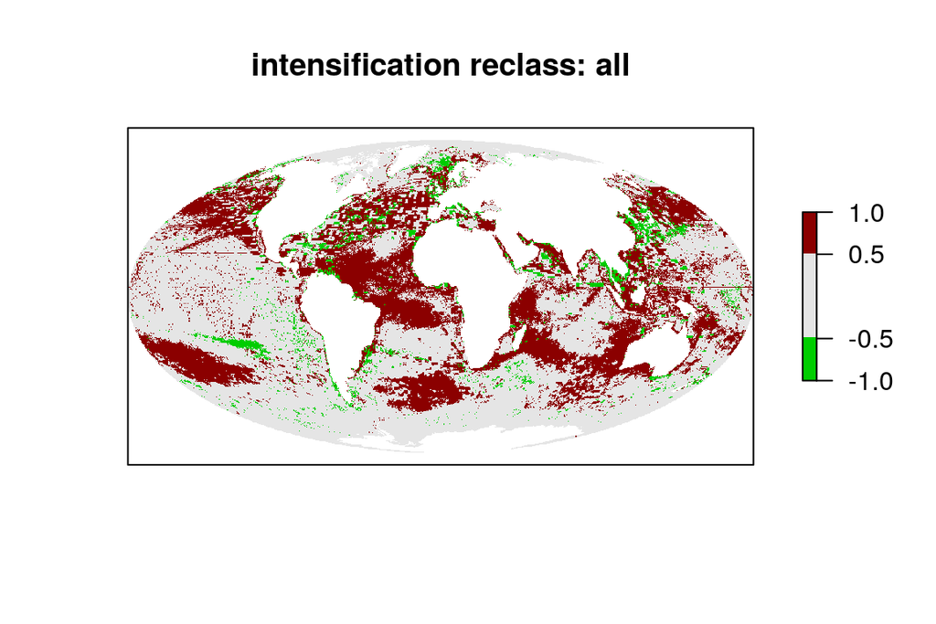

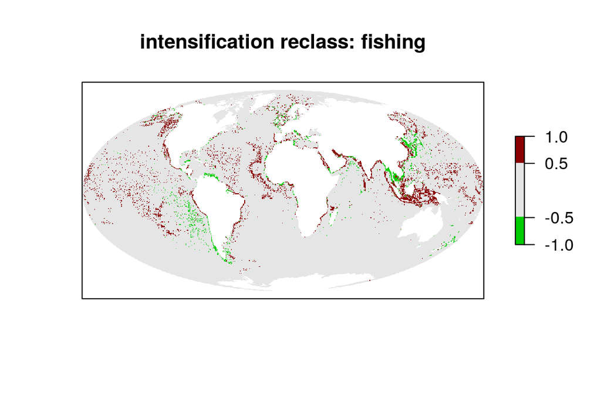

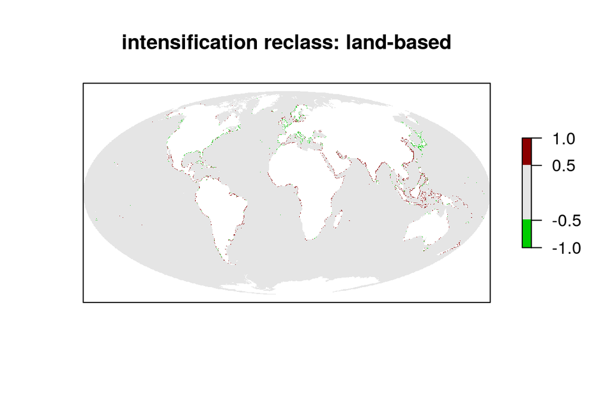

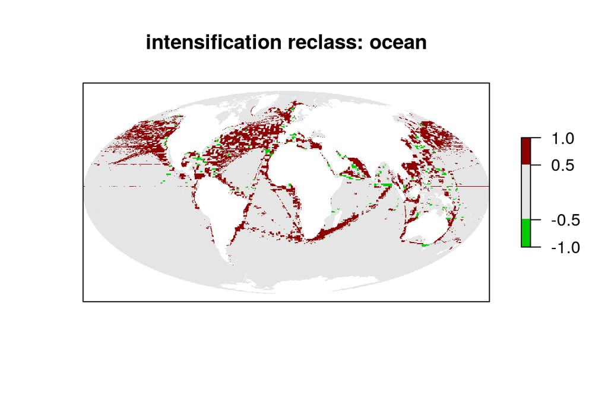

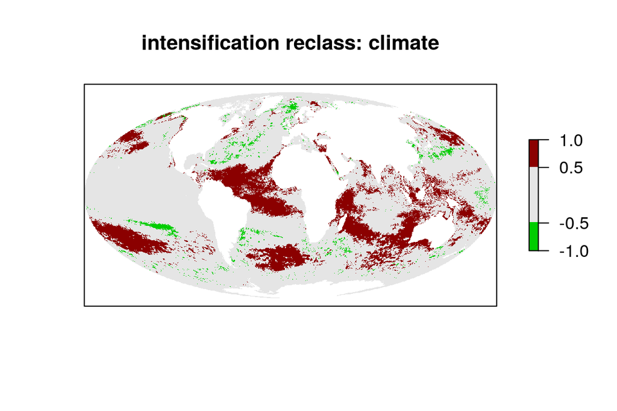

### 2.1.1 Alternative for intens/deintensification map

Instead of taking the top X% of each map separately, find the difference between the two? i.e. intensifying - deintensifying; where negative, more spp are benefiting from decreasing impacts, where positive more spp are suffering from intensifying impacts. This can then be normalized as well.

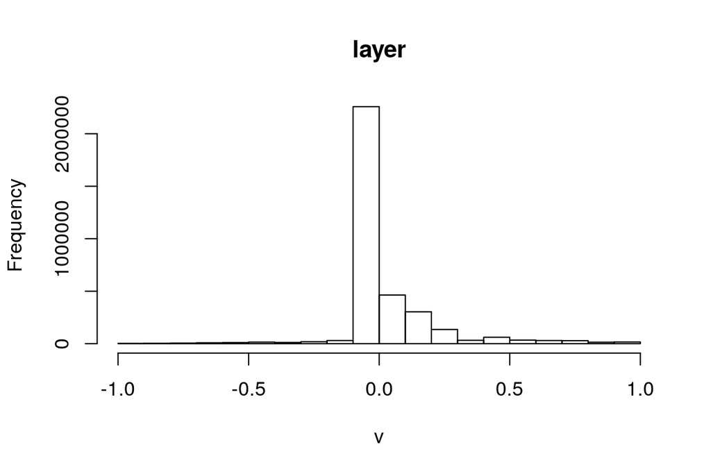

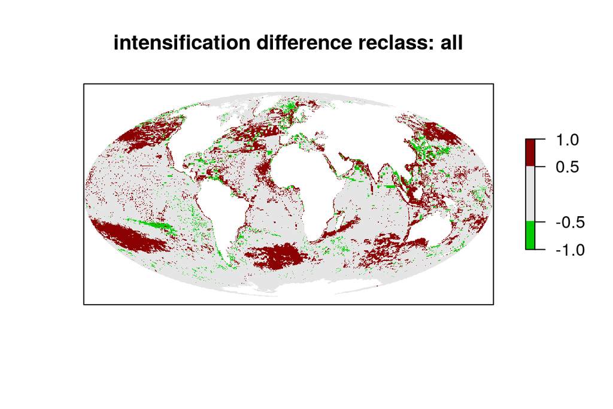

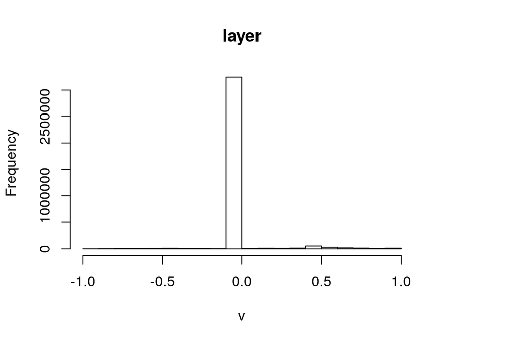

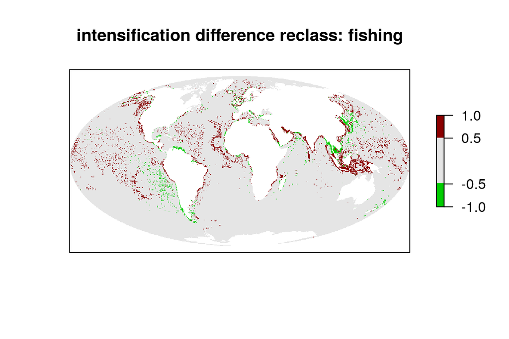

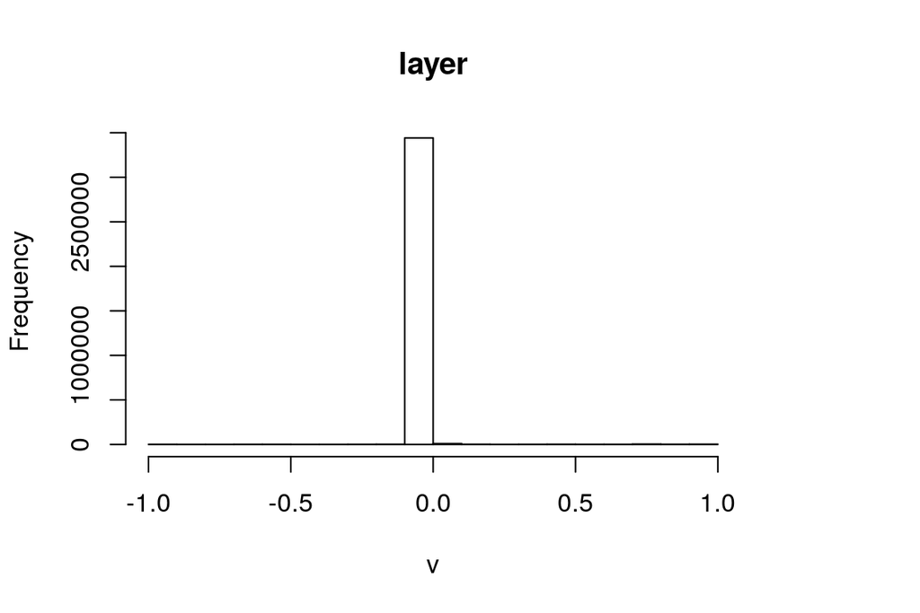

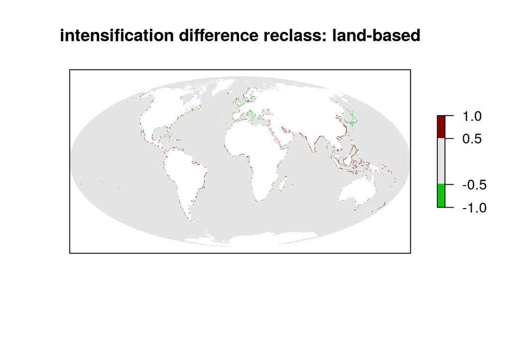

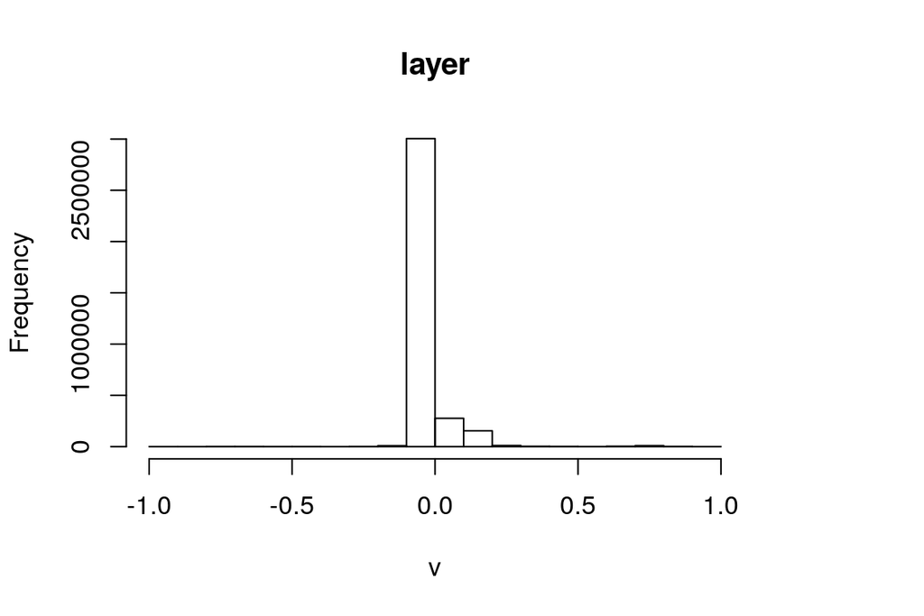

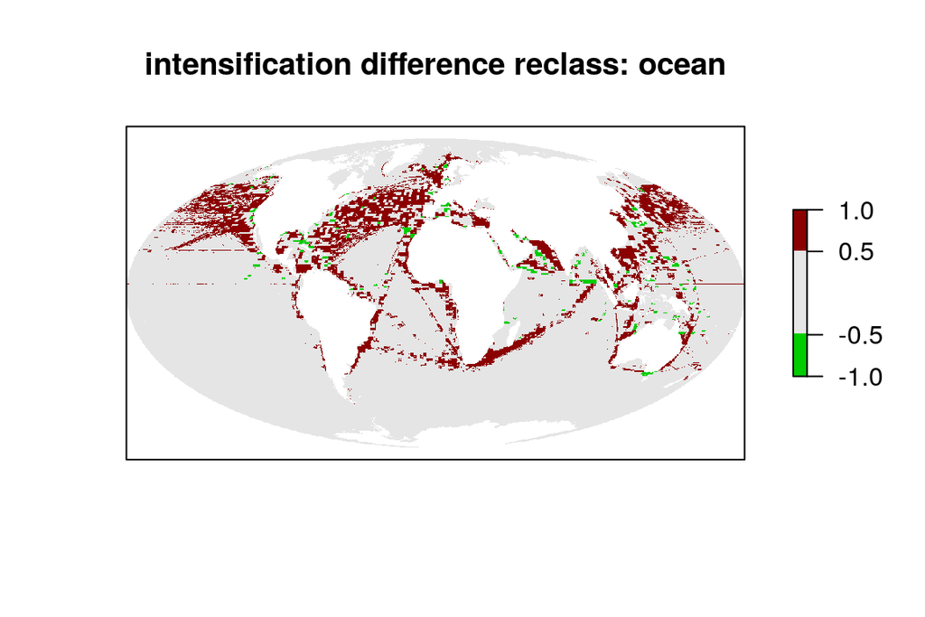

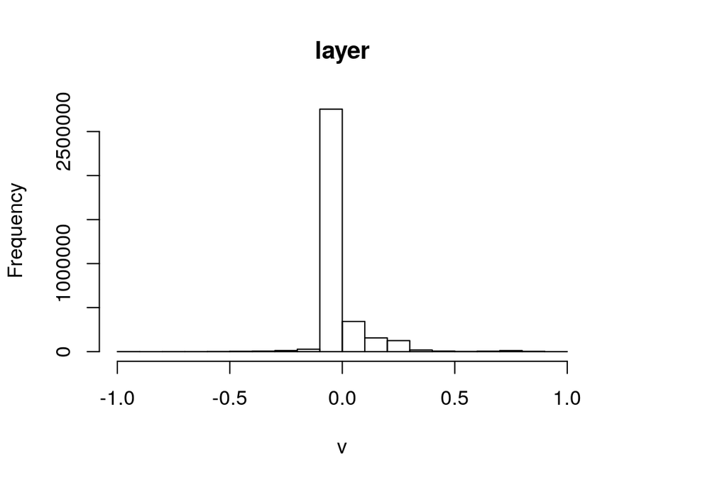

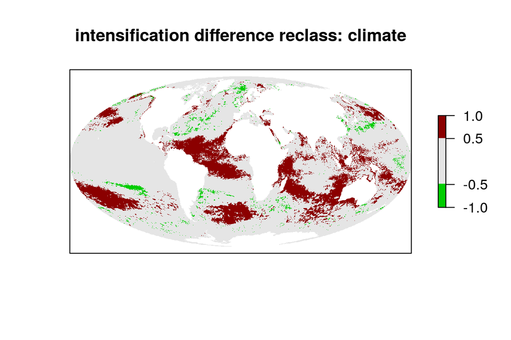

## 2.2 Combine the maps

Here we reclassify to four values (and zero for neutral):

$$\begin{align*}
value = \begin{cases}
+2 &\text{when high impact and intensifying}\\
+1 &\text{when high impact and de-intensifying}\\
-1 &\text{when low impact and intensifying}\\
-2 &\text{when low impact and de-intensifying}\\
0 &else
\end{cases}
\end{align*}$$

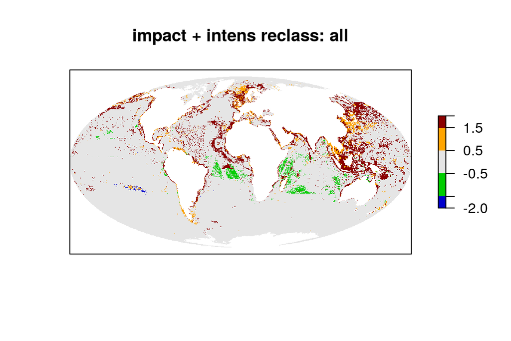

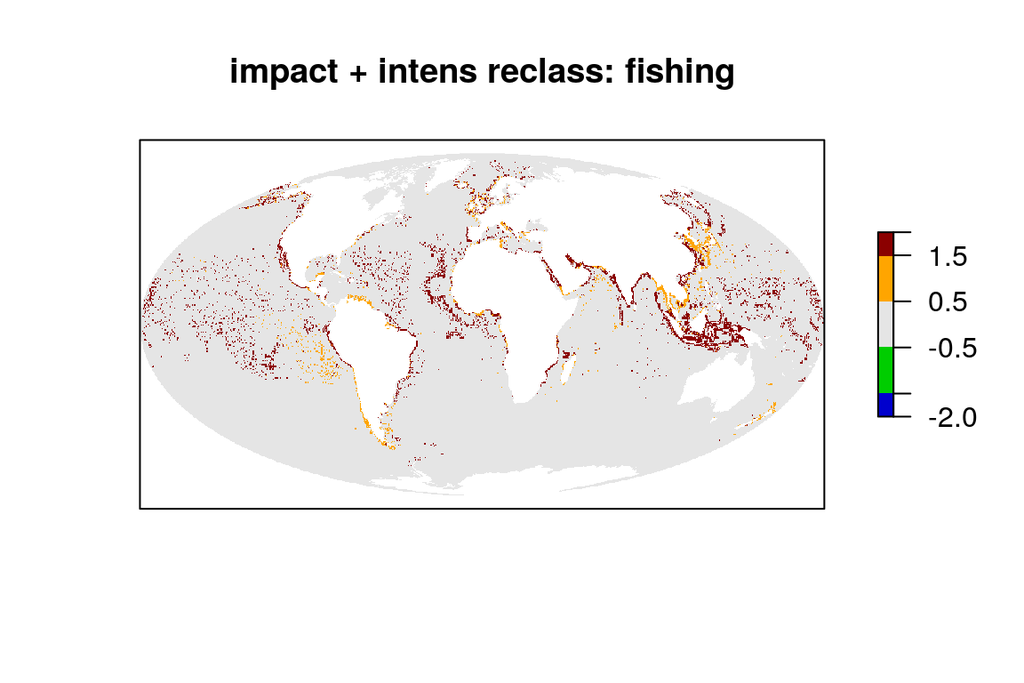

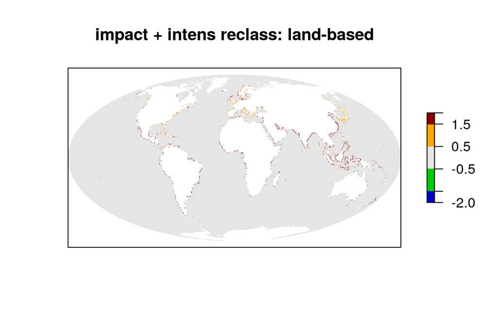

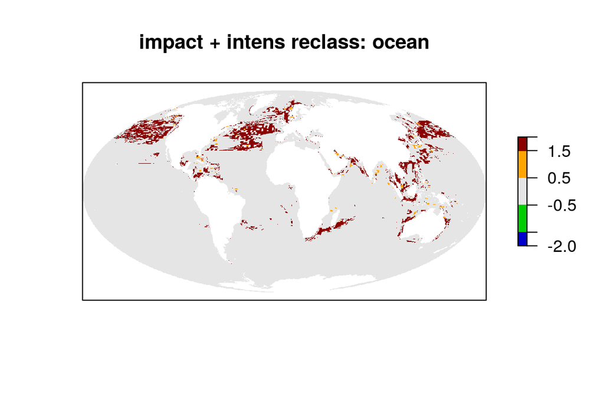

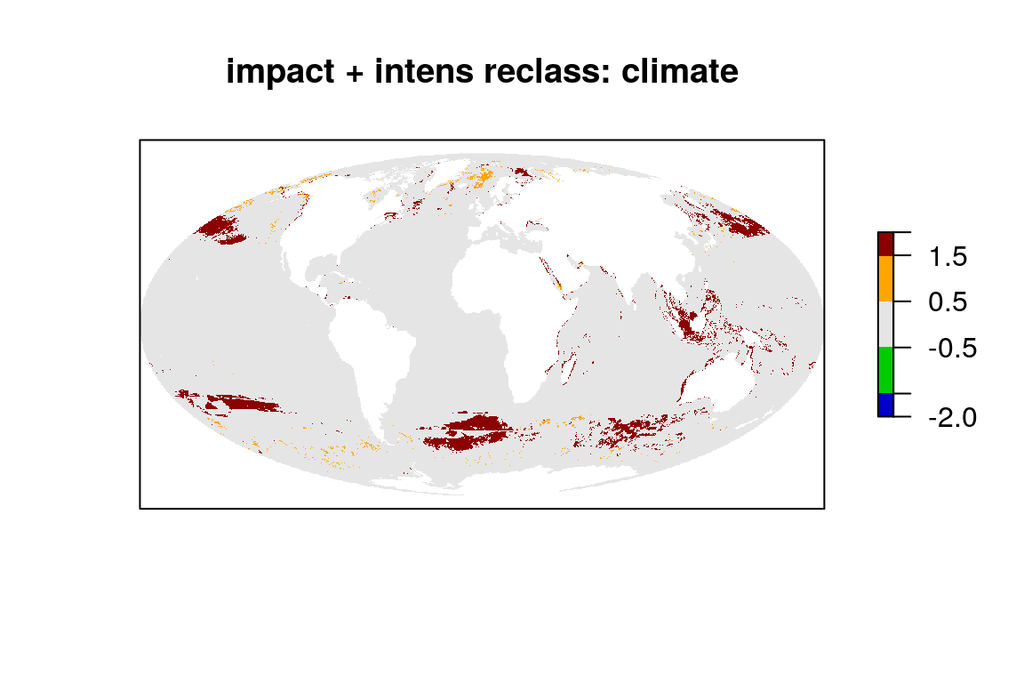